# INFO370-PS03

Marco

2024-07-08

```r
library(tidyverse)
```

```r
library(ggplot2)
library(dplyr)
```

# Model AirBnB Price

## 1.1 Load and clean

### 1.1.1 Load data

```r
abnb <- read_delim("../data/airbnb-bangkok-listings.csv.bz2",
                   col_select = c("bedrooms", "price", "accommodates", "room_type"))
dim(abnb)
```

```
## [1] 17040     4
```

```r
sample_n(abnb, 5)
```

```
## # A tibble: 5 × 4
##   bedrooms price     accommodates room_type
##      <dbl> <chr>            <dbl> <chr>
## 1        1 $550.00              2 Entire home/apt
## 2        1 $974.00              2 Entire home/apt
## 3        1 $550.00              1 Shared room
## 4        1 $1,500.00            1 Private room
## 5        1 $846.00              4 Entire home/apt
```

```r
summary(abnb)
```

```
##     bedrooms         price            accommodates     room_type
##  Min.   : 1.000   Length:17040       Min.   : 0.000   Length:17040
##  1st Qu.: 1.000   Class :character   1st Qu.: 2.000   Class :character
##  Median : 1.000   Mode  :character   Median : 2.000   Mode  :character
##  Mean   : 1.373                      Mean   : 3.134
##  3rd Qu.: 1.000                      3rd Qu.: 4.000
##  Max.   :50.000                      Max.   :16.000
##  NA's   :1840
```

```r
table(abnb$room_type)
```

```
##
## Entire home/apt      Hotel room    Private room     Shared room
##            9322             874            6186             658
```

There are 17040 rows of data. I selected bedrooms, price, room type and accommodates columns The price value was in character with dollar sign. There are 1840 NAs in bedroom column. The range seems to be reasonable with exception of maximum bedroom of 50 (still in acceptable range).

### 1.1.2 Do the basic data cleaning

```r
airbnb <- abnb %>%
  mutate(price = as.numeric(gsub("[$,]", "", price))) %>%
  filter(!is.na(bedrooms))
summary(airbnb)
```

```
##     bedrooms          price         accommodates     room_type
##  Min.   : 1.000   Min.   :     6   Min.   : 1.000   Length:15200
##  1st Qu.: 1.000   1st Qu.:   772   1st Qu.: 2.000   Class :character
##  Median : 1.000   Median :  1200   Median : 2.000   Mode  :character
##  Mean   : 1.373   Mean   :  2284   Mean   : 3.211
##  3rd Qu.: 1.000   3rd Qu.:  2000   3rd Qu.: 4.000
##  Max.   :50.000   Max.   :335482   Max.   :16.000
```

### 1.1.3 Analyze the distribution of price.

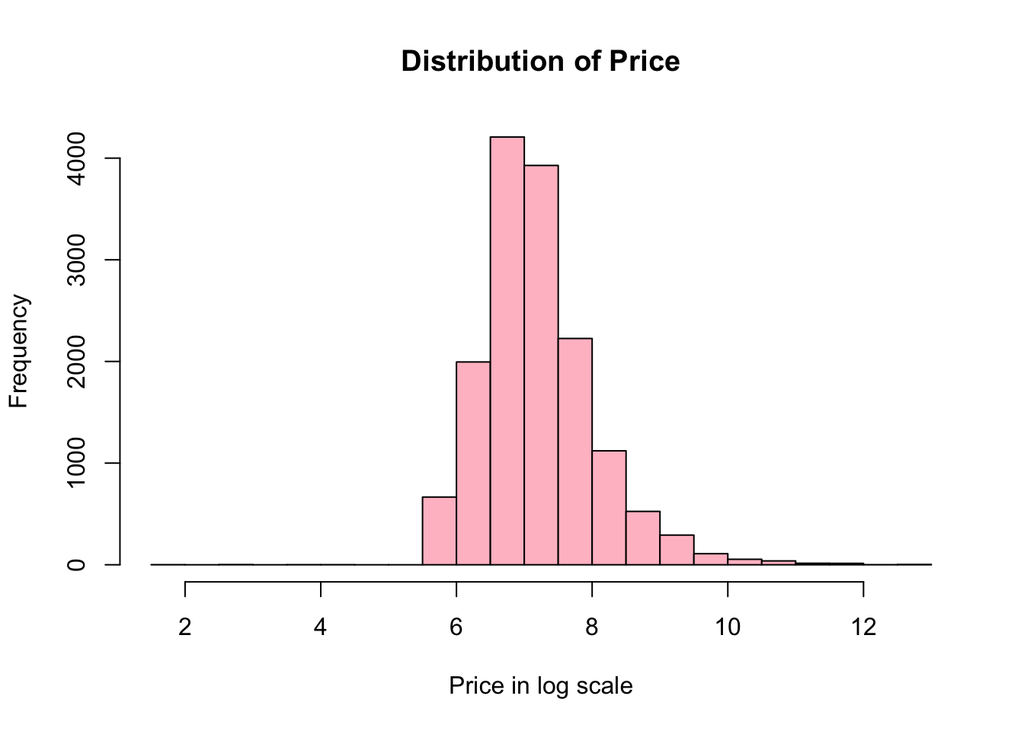

```r
hist(log(airbnb$price), breaks = 30, main = "Distribution of Price", xlab = "Price in log scale", col = "pink")
```

The distribution of price is extremely right skewed. It looks relatively normal in log scale but still have long tail on right.

### 1.1.4 Convert the number of bedrooms into 1, 2, 3, 4+

```r
airbnb <- airbnb %>%
  mutate(
    bedrooms = cut(bedrooms,
                   breaks = c(1, 2, 3, 4, Inf),
                   labels = c("1", "2", "3", "4+"),
                   right = FALSE)
  )
```

## 1.2 Model

### 1.2.1 Run a linear regression

```r
m <- lm(price ~ bedrooms, data = airbnb)
summary(m)
```

```
##
## Call:
## lm(formula = price ~ bedrooms, data = airbnb)
##
## Residuals:
##    Min     1Q Median     3Q    Max
##  -8271  -1142   -754   -176 333740
##
## Coefficients:
##             Estimate Std. Error t value Pr(>|t|)
## (Intercept)  1742.27      63.04  27.637   <2e-16 ***
## bedrooms2    1481.00     158.43   9.348   <2e-16 ***
## bedrooms3    3317.37     292.21  11.353   <2e-16 ***
## bedrooms4+   6592.19     329.86  19.985   <2e-16 ***
## ---
## Signif. codes:  0 '***' 0.001 '**' 0.01 '*' 0.05 '.' 0.1 ' ' 1
##
## Residual standard error: 6884 on 15196 degrees of freedom
## Multiple R-squared:  0.03551,    Adjusted R-squared:  0.03532
## F-statistic: 186.5 on 3 and 15196 DF,  p-value: < 2.2e-16
```

The result shows that when the Airbnb has one bedroom would be approximately $1742.27 The airbnb with two bedrooms would be approximately $1481.00 more expensive than the one with one bedroom. The airbnb with 3 bedrooms would be approximately $3317.37 more expensive than the one with one bedroom. The airbnb with 4 or more bedrooms would be approximately $6592.19 more expensive than the one with one bedroom. The result shows that bedroom variables are statistically significant with P value of $2e-16$ The $R^2$ of 0.03551 indicates the model didn’t do well on capturing the relationship between price and bedrooms

### 1.2.2 repeat the process with log price

```r
m_log <- lm(log(price) ~ bedrooms, data = airbnb)
summary(m_log)
```

```
##
## Call:
## lm(formula = log(price) ~ bedrooms, data = airbnb)
##
## Residuals:
##     Min      1Q  Median      3Q     Max
## -5.2233 -0.4640 -0.1003  0.3521  5.7083
##
## Coefficients:
##             Estimate Std. Error t value Pr(>|t|)
## (Intercept) 7.015033   0.006743 1040.37   <2e-16 ***
## bedrooms2   0.678053   0.016945   40.01   <2e-16 ***
## bedrooms3   1.124857   0.031255   35.99   <2e-16 ***
## bedrooms4+  1.371225   0.035281   38.87   <2e-16 ***
## ---
## Signif. codes:  0 '***' 0.001 '**' 0.01 '*' 0.05 '.' 0.1 ' ' 1
##
## Residual standard error: 0.7363 on 15196 degrees of freedom
## Multiple R-squared:  0.2034, Adjusted R-squared:  0.2032
## F-statistic:  1293 on 3 and 15196 DF,  p-value: < 2.2e-16
```

The result shows that when the Airbnb has one bedroom would be approximately 7.015033 log price The airbnb with two bedrooms would be approximately 0.678053 log price more expensive than the one with one bedroom. The airbnb with 3 bedrooms would be approximately 1.124857 log price more expensive than the one with one bedroom. The airbnb with 4 or more bedrooms would be approximately 1.371225 log price more expensive than the one with one bedroom. The result shows that bedroom variables are statistically significant with P value of $2e-16$ The $R^2$ of 0.2034 indicates the the model with log price perform better on capturing the relationship between price and bedrooms compare to the model with normal price.

### 1.2.3 add two more variables to the model

```r
airbnb <- airbnb %>%
  mutate(
    accommodates = cut(accommodates,
                   breaks = c(1, 2, 3, 4, Inf),
                   labels = c("1", "2", "3", "4 and more"),
                   right = FALSE)
  )
```

```r
m_log <- lm(log(price) ~ bedrooms + room_type + accommodates, data = airbnb)
summary(m_log)
```

```
##
## Call:
## lm(formula = log(price) ~ bedrooms + room_type + accommodates,
##     data = airbnb)
##
## Residuals:
##     Min      1Q  Median      3Q     Max
## -5.1923 -0.4473 -0.0858  0.3292  5.7393
##
## Coefficients:
##                        Estimate Std. Error t value Pr(>|t|)
## (Intercept)             6.90067    0.03196 215.886  < 2e-16 ***
## bedrooms2               0.50867    0.02084  24.406  < 2e-16 ***
## bedrooms3               0.93794    0.03384  27.713  < 2e-16 ***
## bedrooms4+              1.20967    0.03686  32.816  < 2e-16 ***
## room_typeHotel room     0.13318    0.02759   4.827 1.40e-06 ***
## room_typePrivate room  -0.05833    0.01288  -4.528 6.01e-06 ***
## room_typeShared room   -0.68692    0.03305 -20.786  < 2e-16 ***
## accommodates2           0.14170    0.03173   4.466 8.02e-06 ***
## accommodates3           0.20483    0.03469   5.904 3.63e-09 ***
## accommodates4 and more  0.31357    0.03316   9.455  < 2e-16 ***
## ---
## Signif. codes:  0 '***' 0.001 '**' 0.01 '*' 0.05 '.' 0.1 ' ' 1
##
## Residual standard error: 0.7182 on 15190 degrees of freedom
## Multiple R-squared:  0.2424, Adjusted R-squared:  0.2419
## F-statistic: 539.9 on 9 and 15190 DF,  p-value: < 2.2e-16
```

The refernce categories used the airbnb of 1 bedroom, Entire home/apt, and accomodating 1 person. The intercept means that the estimated log(price) for refernce category would be 6.90067 It’s interesting to see that the price would be more expensive as airbnb has more bedrooms or accomodates more people. These might be related since more rooms would essentially have more people to live. It’s also interesting to see Hotel room cost more money than Entire home/apt and Private room or shared room cost less. Compared to the previous model the $R^2$ increased a bit, which means that including more factors `room type` and `accomodates` increase the precision of the model but since $R^2$ is still relatively low (0.2424), it might indicate that there are other factors influencing the price.

## 1.3 Interaction effects

### 1.3.1 Create the additional dummies

```r
airbnb <- airbnb %>%
  mutate("br2+" = !bedrooms %in% c(1),
         "ac3+" = !accommodates %in% c(1, 2))
```

### 1.3.2 Estimate the model

```r
mi <- lm(log(price) ~ `br2+` * `ac3+` + room_type, data = airbnb)
summary(mi)
```

```
##
## Call:
## lm(formula = log(price) ~ `br2+` * `ac3+` + room_type, data = airbnb)
##
## Residuals:
##     Min      1Q  Median      3Q     Max
## -5.1966 -0.4658 -0.0940  0.3308  5.7350
##
## Coefficients:
##                       Estimate Std. Error t value Pr(>|t|)
## (Intercept)            7.03251    0.01035 679.688  < 2e-16 ***
## `br2+`TRUE             0.39328    0.05673   6.932 4.31e-12 ***
## `ac3+`TRUE             0.10875    0.01477   7.365 1.86e-13 ***
## room_typeHotel room    0.13463    0.02794   4.818 1.46e-06 ***
## room_typePrivate room -0.04415    0.01308  -3.376 0.000738 ***
## room_typeShared room  -0.71620    0.02989 -23.961  < 2e-16 ***
## `br2+`TRUE:`ac3+`TRUE  0.36446    0.05961   6.114 9.98e-10 ***
## ---
## Signif. codes:  0 '***' 0.001 '**' 0.01 '*' 0.05 '.' 0.1 ' ' 1
##
## Residual standard error: 0.7292 on 15193 degrees of freedom
## Multiple R-squared:  0.2188, Adjusted R-squared:  0.2185
## F-statistic: 709.2 on 6 and 15193 DF,  p-value: < 2.2e-16
```

### 1.3.3 Interpret the results

1. The reference category is the Entire home/apt airbnb with less than 2 bedroom and accomodates less than 3 people.
2. The listing would be approximately worth 0.39328 log price more if it has two bedrooms but doesn’t accomodate more than 2 people.
3. The listing would be approximately worth 0.10875 log price more if it has single bedroom and accomodates 3 or more people.
4. The listing would be approximately worth 0.86649 log price more if it has at least 2 bedrooms and at least 3 accomodates

### 1.3.4 Does the interaction effect capture important price behavior?

The interaction effect does capture the important price behavior. Since the coefficient of interaction term is 0.36446 and it’s statistically significant (p-value < 0.05). It indicates that listings with at least 2 bedrooms and acommodate at least 3 people have additional price effect on individual effect of 2+ bedrooms or 3+ accommodates.

# 2 When will we hit 2C of global warming?

## 2.1 Load and prepare

### 2.1.1 Load data

```r
hc <- read_delim("../data/hadcrut-5.0.2.0-annual.csv.bz2")
head(hc, 5)
```

```
## # A tibble: 5 × 4
##    Time `Anomaly (deg C)` `Lower confidence limit (2.5%)` Upper confidence lim…¹
##   <dbl>             <dbl>                           <dbl>                  <dbl>
## 1  1850            -0.418                          -0.589                -0.246
## 2  1851            -0.233                          -0.412                -0.0548
## 3  1852            -0.229                          -0.409                -0.0494
## 4  1853            -0.270                          -0.430                -0.111
## 5  1854            -0.292                          -0.433                -0.150
## # ℹ abbreviated name: ¹`Upper confidence limit (97.5%)`
```

```r
hc <- hc %>%
  rename(
    Anomaly = `Anomaly (deg C)`,
    Cl_low = `Lower confidence limit (2.5%)`,
    Cl_high = `Upper confidence limit (97.5%)`
  )
head(hc, 5)
```

```
## # A tibble: 5 × 4
##    Time Anomaly Cl_low Cl_high
##   <dbl>   <dbl>  <dbl>   <dbl>
## 1  1850  -0.418 -0.589 -0.246
## 2  1851  -0.233 -0.412 -0.0548
## 3  1852  -0.229 -0.409 -0.0494
## 4  1853  -0.270 -0.430 -0.111
## 5  1854  -0.292 -0.433 -0.150
```

### 2.1.2 Baseline anomaly

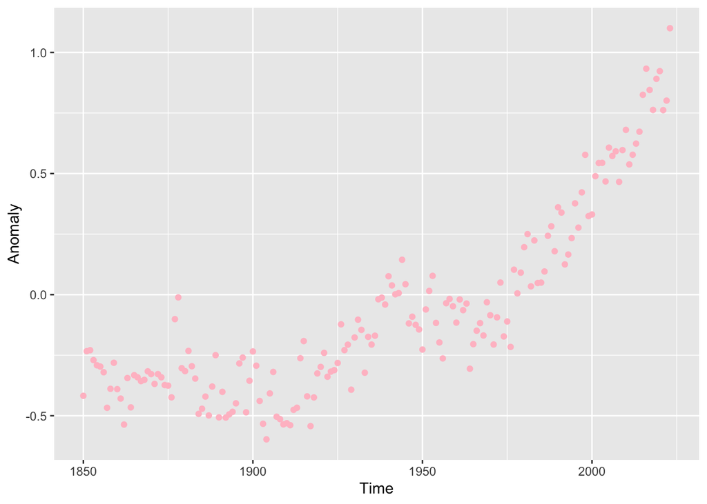

```r
ggplot(hc, aes(x = Time, y = Anomaly)) +
  geom_point(col = "pink")
```

I saw a exponential growth in Anomaly over time. The growing rate was relatively low in 1850 to 1900. And it started growing faster and faster.

### 2.2.1 Compute the baseline anomaly

```r
bl_Anomaly <- hc %>%
  filter(Time <= 1900) %>%
  summarise(mean_anomaly = mean(Anomaly)) %>%
  pull(mean_anomaly)
bl_Anomaly
```

```
## [1] -0.3564947
```

the baseline anomaly (for 1850-1900) is -0.3564947

### 2.2.2 Create a newc olumn that describes the temperature anomaly

```r
hc <- hc %>%
  mutate(Anomaly_above = Anomaly - bl_Anomaly)
head(hc, 5)
```

```
## # A tibble: 5 × 5
##    Time Anomaly Cl_low Cl_high Anomaly_above
##   <dbl>   <dbl>  <dbl>   <dbl>         <dbl>
## 1  1850  -0.418 -0.589 -0.246        -0.0612
## 2  1851  -0.233 -0.412 -0.0548        0.123
## 3  1852  -0.229 -0.409 -0.0494        0.127
## 4  1853  -0.270 -0.430 -0.111         0.0861
## 5  1854  -0.292 -0.433 -0.150         0.0650
```

## 2.3 When will we hit +2C?

### 2.3.1 Make a plot that shows the post-1960 data

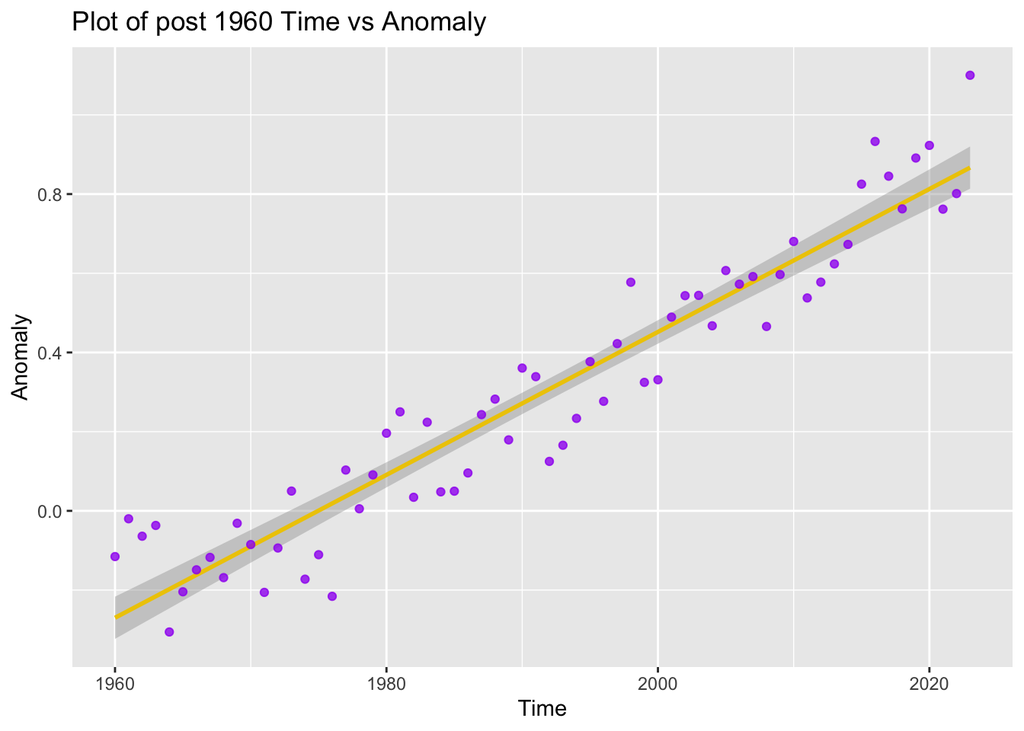

```r
hc_1960 <- hc %>%
  filter(Time >= 1960)

ggplot(hc_1960, aes(y = Anomaly, x = Time)) +
  geom_smooth(method = "lm", col = "gold2")+
  geom_point(alpha = 0.8, col = "purple") +
  labs(title = "Plot of post 1960 Time vs Anomaly")
```

In my opinion, the regression line pretty much describe the behavior of the trend.

### 2.3.2 Estimate a linear regression model

```r
m <- lm(Anomaly_above ~ I(Time-2000), data = hc_1960)
summary(m)
```

```
##
## Call:
## lm(formula = Anomaly_above ~ I(Time - 2000), data = hc_1960)
##
## Residuals:
##      Min       1Q   Median       3Q      Max
## -0.23456 -0.09528  0.01265  0.07685  0.23318
##
## Coefficients:
##                 Estimate Std. Error t value Pr(>|t|)
## (Intercept)    0.8083178  0.0148495   54.43   <2e-16 ***
## I(Time - 2000) 0.0180459  0.0007303   24.71   <2e-16 ***
## ---
## Signif. codes:  0 '***' 0.001 '**' 0.01 '*' 0.05 '.' 0.1 ' ' 1
##
## Residual standard error: 0.1079 on 62 degrees of freedom
## Multiple R-squared:  0.9078, Adjusted R-squared:  0.9063
## F-statistic: 610.7 on 1 and 62 DF,  p-value: < 2.2e-16
```

$R^2$ is 0.9078 which indicates that the model did pretty well on capturing the relationship between Anomaly above industrial baseline and time after 1960.

### 2.3.3 Interpret the slope

The slope is 0.0180459 which means that an additional year would increase the anomaly above the industrial baseline by 0.0180459

### 2.3.4 What does the intercept mean

1. When use years of (1999, 2000, 2001, etc) the intercept it the Anomaly above industrial two thousand years ago
2. When use years relative to 2000, the intercept means the Anomaly above industrial on year 2000 Since P value is a very small number $2e-16$ that less than 0.05, the Time is statistically significant

### 2.3.5 How much above the pre-industrial baseline is the world now, in 2024

```r
0.0180459 * 24 + 0.8083178
```

```
## [1] 1.241419
```

The anomaly would be 1.241419 now in 2024 above pre-industrial baseline.

### 2.3.6 Which year will the trend hit 1.5C, and when will it hit 2C

```r
(1.5-0.8083178)/0.0180459
```

```
## [1] 38.32905
```

```r
(2-0.8083178)/0.0180459
```

```
## [1] 66.03617
```

The trend will hit 1.5C on around 2038 and it will hit 2C on around 2066

### 2.3.7 Might the thresholds be actually crossed earlier or later than what you computed？

I would expect it would expect the thresholds to be earlier than I computed. Since it’s depending on emissions, technology development, government policy etc. These factors are not linear, so a linear model might not accurately capture the relationship.

## 2.4 Is the trend quadratic?

### 2.4.1 Estimate a linear regression model

```r
qm <- lm(Anomaly_above ~ I(Time - 2000) + I((Time - 2000)^2), data = hc_1960)
summary(qm)
```

```
##
## Call:
## lm(formula = Anomaly_above ~ I(Time - 2000) + I((Time - 2000)^2),
##     data = hc_1960)
##
## Residuals:
##      Min       1Q   Median       3Q      Max
## -0.22071 -0.07461 -0.01073  0.07632  0.20261
##
## Coefficients:
##                     Estimate Std. Error t value Pr(>|t|)
## (Intercept)        7.714e-01  1.763e-02  43.757   <2e-16 ***
## I(Time - 2000)     2.038e-02  9.711e-04  20.983   <2e-16 ***
## I((Time - 2000)^2) 1.371e-04  4.097e-05   3.347   0.0014 **
## ---
## Signif. codes:  0 '***' 0.001 '**' 0.01 '*' 0.05 '.' 0.1 ' ' 1
##
## Residual standard error: 0.1 on 61 degrees of freedom
## Multiple R-squared:  0.9221, Adjusted R-squared:  0.9196
## F-statistic: 361.2 on 2 and 61 DF,  p-value: < 2.2e-16
```

### 2.4.2 Are both the linear and the quadratic term statistically significant?

Both lienar and quadratic term are statistically significant since both of their P values are small numbers less than 0.05. It indicates that the optimal trend should also have a quadratic relationship.

### 2.4.3 What does R^2 suggest

The $R^2$ of 0.9221 suggests that the model did well on capturing the temperature trend. Its $R^2$ is higher than the $R^2$ of linear model which means that the quadratic model perform better on captureing the temperature trend.

### 2.4.4 Make a plot that shows the temperature anomaly over years.

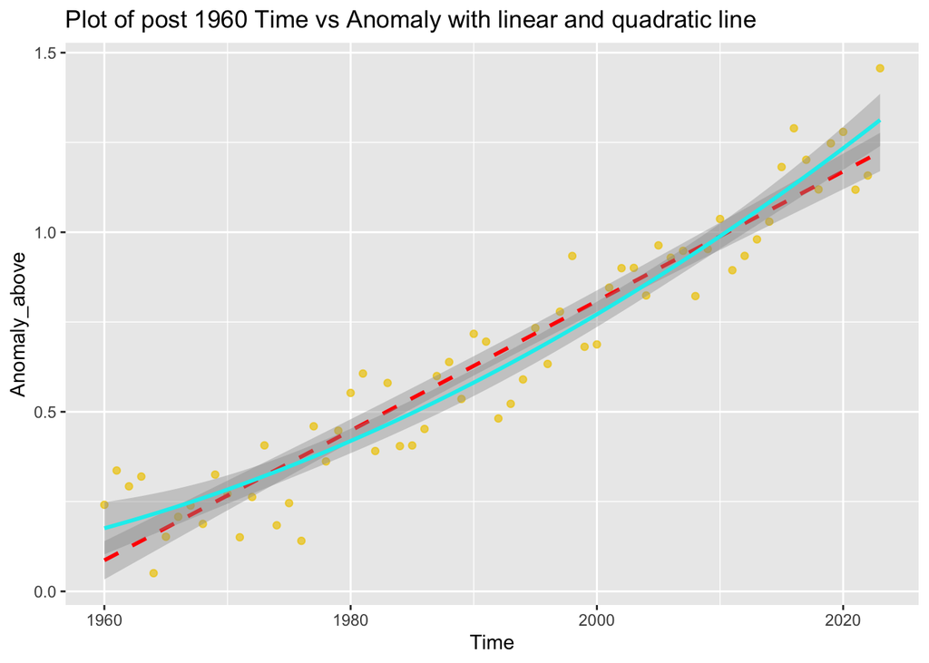

```r
ggplot(hc_1960, aes(x = Time, y = Anomaly_above)) +
  geom_point(alpha = 0.7, col = "gold2") +
  geom_smooth(method = "lm", col = "red", formula = y ~ x, linetype = "dashed") +
  geom_smooth(method = "lm", formula = y ~ x + I(x^2), col = "cyan2") +
  labs(title = "Plot of post 1960 Time vs Anomaly with linear and quadratic line")
```

### 2.4.6 compute predictions till 2050

```r
years <- 24:50
predictions <- 0.7714 + 0.02038*years + 1.371*10^(-4) * years^2
pd <- data.frame(Year = years+2000, Prediction = predictions)
pd
```

```
##    Year Prediction
## 1  2024   1.339490
## 2  2025   1.366587
## 3  2026   1.393960
## 4  2027   1.421606
## 5  2028   1.449526
## 6  2029   1.477721
## 7  2030   1.506190
## 8  2031   1.534933
## 9  2032   1.563950
## 10 2033   1.593242
## 11 2034   1.622808
## 12 2035   1.652647
## 13 2036   1.682762
## 14 2037   1.713150
## 15 2038   1.743812
## 16 2039   1.774749
## 17 2040   1.805960
## 18 2041   1.837445
## 19 2042   1.869204
## 20 2043   1.901238
## 21 2044   1.933546
## 22 2045   1.966127
## 23 2046   1.998984
## 24 2047   2.032114
## 25 2048   2.065518
## 26 2049   2.099197
## 27 2050   2.133150
```

### 2.4.7 when will the world cross the 1.5C and 2C thresholds?

Based on the prediction, if the quadratic trend remain the same, the world will cross 1.5C at 2030 and cross 2.0C at 2047. Compare to the linear trend the world will hit 1.5C and 2C sooner.

## 3 Interpret regression results in the literature

### 3.3 How is Financial distress related to mental health?

The slope is 2.32 which indicates that financial distress would on average make mental health worse. The result is statistically significant since the P value is less than $.05$

## How many hours?

Around 8